# Reproducible Research: Peer Assessment 1

## Load the data

Data file activity.csv is located in working directory

```r
DataFile <- read.csv("activity.csv")
```

## Preprocess the data

```r
#convert data
DataFile$date <- as.Date(DataFile$date , format = "%Y-%m-%d")

#create dataframe with total number of steps per day
DataFile.day <- aggregate(DataFile$steps, by=list(DataFile$date), sum)
names(DataFile.day)[1] <-"day"
names(DataFile.day)[2] <-"steps"

#create dataframe with total number of steps per interval
DataFile.interval <- aggregate(DataFile$steps, by=list(DataFile$interval), sum, na.rm=TRUE, na.action=NULL)
names(DataFile.interval)[1] <-"interval"
names(DataFile.interval)[2] <-"steps"

#create dataframe with mean number of steps per interval
DataFile.mean.interval <- aggregate(DataFile$steps, by=list(DataFile$interval), mean, na.rm=TRUE, na.action=NULL)
names(DataFile.mean.interval)[1] <-"interval"
names(DataFile.mean.interval)[2] <-"mean.steps"
```

## What is mean total number of steps taken per day?

# Histogram of total number of steps taken per day

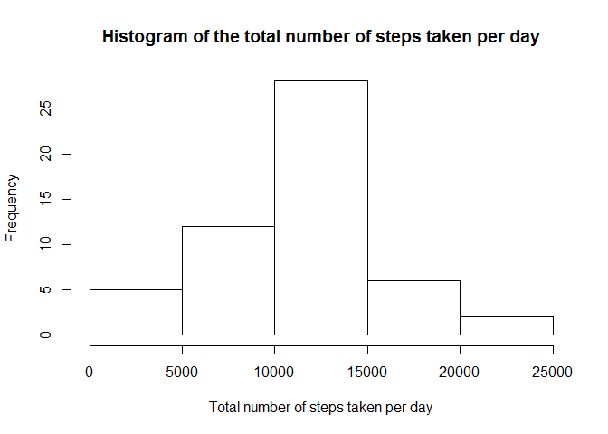

```r
hist(DataFile.day$steps,
     main = "Histogram of the total number of steps taken per day", xlab = "Total number of steps taken per day")
```

# Calculate and report the mean and median number of steps taken per day Mean number of steps taken per day:

```r
mean(DataFile.day$steps, na.rm = TRUE)
```

```
## [1] 10766.19
```

Median number of steps taken per day:

```r
median(DataFile.day$steps, na.rm = TRUE)
```

```
## [1] 10765
```

## What is the average daily activity pattern?

# Time series plot

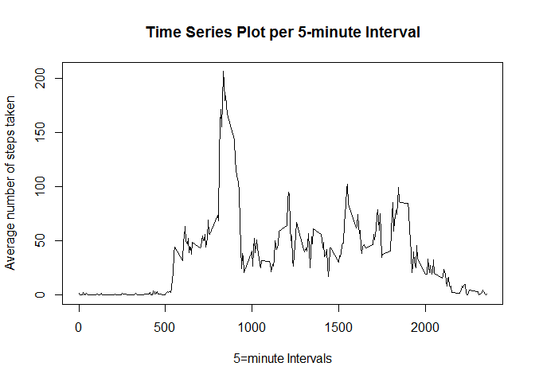

```r
plot(DataFile.mean.interval$interval, DataFile.mean.interval$mean.steps, type="n",
     main="Time Series Plot per 5-minute Interval",
     xlab = "5=minute Intervals",
     ylab = "Average number of steps taken")
lines(DataFile.mean.interval$interval, DataFile.mean.interval$mean.steps, type="l")
```

# Which 5-minute Interval, on average across all the days in the dataset, contains the maximum number of steps

```r
DataFile.mean.interval[which.max(DataFile.mean.interval$mean.steps),1]
```

```
## [1] 835
```

# Calculate and report the total number of missing values in the dataset

```r
sum(is.na(DataFile$steps))
```

```
## [1] 2304
```